GUIDEseq package demo  
Bioc2017 Boston  
July 26th 2017  
By Lihua Julie Zhu

# References

Zhu LJ, Lawrence M, Gupta A, Pages H, Kucukural A, Garber M and Wolfe SA (2017). “GUIDEseq: a bioconductor package to analyze GUIDE-Seq datasets for CRISPR-Cas nucleases.” BMC Genomics, 18(1). http://bmcgenomics.biomedcentral.com/articles/10.1186/s12864-017-3746-y.

Main text of the article: Use cases

Additional File 1: Preprocessing steps to genereate alignment and umi files as input for GUIDEseq

Additional File 2: Installation and use of GUIDEseq (intended for new users of R and Bioconductor)

# First load the GUIDEseq and annotation packages.

We are going to use a dataset generated from human samples, which has been included in the GUIDEseq package. To annotate the targets and off-targets, we need to load Human BSgenome package, Human Transcript and gene identifier mapping packages.

Note: It is critical to use the same version of the genome for sequence mapping (preprocessing) and for sequence analysis in GUIDEseq.

```r
library(CRISPRseekGUIDEseqBioc2017Workshop)
library(GUIDEseq)
library(BSgenome.Hsapiens.UCSC.hg19)
library(TxDb.Hsapiens.UCSC.hg19.knownGene)
library(org.Hs.eg.db)
```

# Here are the commands to learn more about the GUIDEseq package and how to use the two workflow functions to perform GUIDE-seq data analysis for different types of CRISPR system and to compare different experiments.

```r
help(GUIDEseqAnalysis)
help(combineOfftargets)
browseVignettes("GUIDEseq")
```

# Example 1. Analysis of SpCas9 GUIDE-seq data

Although the analysis workflow function GUIDEseqAnalysis has more than 60 parameters for customized analysis, the majority of these parameters are pre-set for analyzing GUIDE-seq data from the most commonly used nuclease, SpCas9. Consequently when analyzing SpCas9 data only a small number of target-specific inputs are required from users.

There are four required inputs.  
1) gRNA.file for specifying a file containing one or more gRNAs in fasta format;  
2) alignment.file for specifying 1-2 files containing the sequence alignment in bam format;  
3) umi.file for specifying 1-2 files containing UMI for each read;  
4) BSgenomeName for specifying the BSgenome object containing the genome sequences  
Please note that if outputDir is not specified, results will be automatically saved in a folder named according to the peak calling/merging/filtering criteria specified, e.g., gRNAmin80window20step20distance40 will be the default outputDir with the following code snippet.

The gRNA file can be created using a text editor or vi. Both alignment and umi files are generated in the preprocessing steps. The analysis results are saved as offTargetAnaysisOfPeaks.xls in the specified output directory.

```r
    umi.inputfile <- c(system.file("extdata", "plusLibraryUMI.txt",
            package = "CRISPRseekGUIDEseqBioc2017Workshop"),
            system.file("extdata", "minusLibraryUMI.txt",
            package = "CRISPRseekGUIDEseqBioc2017Workshop"))
    alignment.inputfile <- c(system.file("extdata","plusLibrary.sort.bam" ,
            package = "CRISPRseekGUIDEseqBioc2017Workshop"),
            system.file("extdata","minusLibrary.sort.bam" ,
            package = "CRISPRseekGUIDEseqBioc2017Workshop"))
    gRNA.file <- system.file("extdata","gRNA.fa", package = "GUIDEseq")
    guideSeqRes <- GUIDEseqAnalysis(
            alignment.inputfile = alignment.inputfile,
            umi.inputfile = umi.inputfile,
            gRNA.file = gRNA.file,
            orderOfftargetsBy = "peak_score",
            descending = TRUE,
            BSgenomeName = Hsapiens, min.reads = 80, n.cores.max = 4)
```

```
## Remove duplicate reads ...
```

```
## Peak calling ...
```

```
## computing coverage for plus strand ...
```

```
## computing coverage for minus strand ...
```

```
## call peaks ...
```

```
## finding local max for chromosome: chr13
```

```
## computing coverage for plus strand ...
```

```
## computing coverage for minus strand ...
```

```
## call peaks ...
```

```
## finding local max for chromosome: chr13
```

```
## computing coverage for plus strand ...
```

```
## computing coverage for minus strand ...
```

```
## call peaks ...
```

```
## finding local max for chromosome: chr13
```

```
## combine plus and minus peaks ...
```

```
## keep peaks not in merged.gr but present in both peaks1 and peaks2
```

```
## Find unmerged peaks with reads representation in both libraries
```

```
## offtarget analysis ...
```

[output not shown]

```
## >>> Finding all hits in sequence chr13+:66687218:66687225 ...
## >>> DONE searching
```

```
## >>> Finding all hits in sequence chr13+:67161908:67161923 ...
## >>> DONE searching
```

```
## >>> Finding all hits in sequence chr13+:79233416:79233436 ...
## >>> DONE searching
```

```
## >>> Finding all hits in sequence chr13+:96233915:96233932 ...
## >>> DONE searching
```

```
## >>> Finding all hits in sequence chr13+:98226906:98226924 ...
## >>> DONE searching
```

```
## >>> Finding all hits in sequence chr13+:109316130:109316144 ...
## >>> DONE searching
```

```
## >>> Finding all hits in sequence chr13-:29087136:29087137 ...
## >>> DONE searching
```

```
## >>> Finding all hits in sequence chr13-:41110384:41110391 ...
## >>> DONE searching
```

```
## >>> Finding all hits in sequence chr13-:97395652:97395666 ...
## >>> DONE searching
```

```
## >>> Finding all hits in sequence chr13-:115084360:115084375 ...
## >>> DONE searching
```

```
## finish off-target search in sequence 2
## finish off-target search in sequence 1
## finish feature vector building
## finish score calculation
## [1] "Done!"
```

```
## Done with offtarget search!
## Add gene and exon information to offTargets ....
## Extract PAM sequence and n.PAM.mismatch.
```

```
## Please check output file in directory gRNAmin80window20step20distance40
```

```r
    guideSeqRes$offTargets
```

```
##                   offTarget peak_score predicted_cleavage_score
## 3 chr13:+:39262912:39262934       1894                      1.2
## 1 chr13:-:27629404:27629426       1380                      3.2
## 2 chr13:-:88900986:88901008        198                      1.6
##      gRNA.name             gRNAPlusPAM      offTarget_sequence
## 3 HEK239_site4 GGCACTGCGGCTGGAGGTGGNGG AGCAGTGCGGCTAGAGGTGGTGG
## 1 HEK239_site4 GGCACTGCGGCTGGAGGTGGNGG GGCACTGGGGTTGGAGGTGGGGG
## 2 HEK239_site4 GGCACTGCGGCTGGAGGTGGNGG CACACTGCAGCTGGAGGTGGTGG
##   guideAlignment2OffTarget offTargetStrand mismatch.distance2PAM
## 3     A...G.......A.......               +               20,16,8
## 1     .......G..T.........               -                 13,10
## 2     CA......A...........               -              20,19,12
##   n.PAM.mismatch n.guide.mismatch PAM.sequence offTarget_Start
## 3              0                3          TGG        39262912
## 1              0                2          GGG        27629404
## 2              0                3          TGG        88900986
##   offTarget_End chromosome
## 3      39262934      chr13
## 1      27629426      chr13
## 2      88901008      chr13
```

```r
library(GUIDEseq)
gRNA.file <- "~/GUIDEseqSpCas9Input/SpCas9gRNAexample.fa"
alignment.inputfile <- c("~/GUIDEseqSpCas9Input/plusLibrary.sort.bam",
      "~/GUIDEseqSpCas9Input/minusLibrary.sort.bam")
umi.inputfile <- c("~/GUIDEseqSpCas9Input/plusLibraryUMI.txt",
      "~/GUIDEseqSpCas9Input/minusLibraryUMI.txt")
outputDir <- "~/guideSeqResults"
guideSeqResults <- GUIDEseqAnalysis(
     alignment.inputfile = alignment.inputfile,
     umi.inputfile = umi.inputfile,
     gRNA.file = gRNA.file,
     BSgenomeName = Hsapiens,
     outputDir = outputDir)
```

By default, the predicted cleavage score is calculated using the weight matrix and scoring algorithm from the Zhang laboratory. To use the algorithm developed by the Root Laboratory, set the scoring.method = “CFDscore”.

# Example 2: Annotate off-targets

With parameters txdb and orgAnn set to an organism-specific transcript object and gene ID mapping object respectively, off-target sites are annotated to indicate whether the offtargets overlap with gene bodies and whether they fall within an exon. Here is an example for SpCas9 GUIDE-seq data processing that annotates identified potential off-target sites with features from the human genome.

```r
library(TxDb.Hsapiens.UCSC.hg19.knownGene)
library(org.Hs.eg.db)
outputDir <- "~/guideSeqResults"
guideSeqResults <- GUIDEseqAnalysis(
    alignment.inputfile = alignment.inputfile,
    umi.inputfile = umi.inputfile,
    gRNA.file = gRNA.file,
    BSgenomeName = Hsapiens,
    txdb = TxDb.Hsapiens.UCSC.hg19.knownGene,
    orgAnn = org.Hs.egSYMBOL,
    outputDir = outputDir)
```

```
## Remove duplicate reads ...
```

```
## Peak calling ...
```

```
## computing coverage for plus strand ...
```

```
## computing coverage for minus strand ...
```

```
## call peaks ...
```

```
## finding local max for chromosome: chr13
```

```
## computing coverage for plus strand ...
```

```
## computing coverage for minus strand ...
```

```
## call peaks ...
```

```
## finding local max for chromosome: chr13
```

```
## computing coverage for plus strand ...
```

```
## computing coverage for minus strand ...
```

```
## call peaks ...
```

```
## finding local max for chromosome: chr13
```

```
## combine plus and minus peaks ...
```

```
## keep peaks not in merged.gr but present in both peaks1 and peaks2
```

```
## Find unmerged peaks with reads representation in both libraries
```

```
## offtarget analysis ...
```

[output not shown]

[output not shown]

```
## >>> Finding all hits in sequence chr13+:20683165:20683185 ...
## >>> DONE searching
```

```
## >>> Finding all hits in sequence chr13+:20865113:20865133 ...
## >>> DONE searching
```

```
## >>> Finding all hits in sequence chr13+:20979028:20979048 ...
## >>> DONE searching
```

```
## >>> Finding all hits in sequence chr13+:21395595:21395615 ...
## >>> DONE searching
```

```
## >>> Finding all hits in sequence chr13+:21433912:21433925 ...
## >>> DONE searching
```

```
## >>> Finding all hits in sequence chr13+:21531840:21531856 ...
## >>> DONE searching
```

```
## >>> Finding all hits in sequence chr13+:21537218:21537233 ...
## >>> DONE searching
```

```
## >>> Finding all hits in sequence chr13+:21597770:21597790 ...
## >>> DONE searching
```

```
## >>> Finding all hits in sequence chr13+:21955661:21955681 ...
## >>> DONE searching
```

```
## >>> Finding all hits in sequence chr13+:22332147:22332167 ...
## >>> DONE searching
```

```
## >>> Finding all hits in sequence chr13+:22603877:22603897 ...
## >>> DONE searching
```

```
## >>> Finding all hits in sequence chr13+:22911530:22911550 ...
## >>> DONE searching
```

```
## >>> Finding all hits in sequence chr13+:23002153:23002173 ...
## >>> DONE searching
```

```
## >>> Finding all hits in sequence chr13+:23280771:23280783 ...
## >>> DONE searching
```

```
## >>> Finding all hits in sequence chr13+:23799953:23799973 ...
## >>> DONE searching
```

```
## >>> Finding all hits in sequence chr13+:24060919:24060939 ...
## >>> DONE searching
```

```
## >>> Finding all hits in sequence chr13+:24065254:24065274 ...
## >>> DONE searching
```

```
## >>> Finding all hits in sequence chr13+:24493823:24493843 ...
## >>> DONE searching
```

```
## >>> Finding all hits in sequence chr13+:24656963:24656976 ...
## >>> DONE searching
```

```
## >>> Finding all hits in sequence chr13+:24813832:24813841 ...
## >>> DONE searching
```

```
## >>> Finding all hits in sequence chr13+:24977283:24977303 ...
## >>> DONE searching
```

```
## >>> Finding all hits in sequence chr13+:24994998:24995012 ...
## >>> DONE searching
```

```
## >>> Finding all hits in sequence chr13+:25270857:25270860 ...
## >>> DONE searching
```

```
## >>> Finding all hits in sequence chr13+:25401847:25401850 ...
## >>> DONE searching
```

```
## >>> Finding all hits in sequence chr13+:25658368:25658388 ...
## >>> DONE searching
```

```
## >>> Finding all hits in sequence chr13+:25709772:25709792 ...
## >>> DONE searching
```

```
## >>> Finding all hits in sequence chr13+:26444955:26444975 ...
## >>> DONE searching
```

```
## >>> Finding all hits in sequence chr13+:26664550:26664570 ...
## >>> DONE searching
```

```
## >>> Finding all hits in sequence chr13+:26697477:26697485 ...
## >>> DONE searching
```

```
## >>> Finding all hits in sequence chr13+:26711781:26711797 ...
## >>> DONE searching
```

```
## >>> Finding all hits in sequence chr13+:27307572:27307592 ...
## >>> DONE searching
```

```
## >>> Finding all hits in sequence chr13+:27321560:27321580 ...
## >>> DONE searching
```

```
## >>> Finding all hits in sequence chr13+:27622701:27622721 ...
## >>> DONE searching
```

```
## >>> Finding all hits in sequence chr13+:27819707:27819721 ...
## >>> DONE searching
```

```
## >>> Finding all hits in sequence chr13+:27933064:27933084 ...
## >>> DONE searching
```

```
## >>> Finding all hits in sequence chr13+:28034322:28034336 ...
## >>> DONE searching
```

```
## >>> Finding all hits in sequence chr13+:28089775:28089795 ...
## >>> DONE searching
```

```
## >>> Finding all hits in sequence chr13+:28176176:28176196 ...
## >>> DONE searching
```

```
## >>> Finding all hits in sequence chr13+:28356573:28356593 ...
## >>> DONE searching
```

```
## >>> Finding all hits in sequence chr13+:28461017:28461032 ...
## >>> DONE searching
```

```
## >>> Finding all hits in sequence chr13+:28624328:28624348 ...
## >>> DONE searching
```

```
## >>> Finding all hits in sequence chr13+:28629852:28629872 ...
## >>> DONE searching
```

```
## >>> Finding all hits in sequence chr13+:28698872:28698891 ...
## >>> DONE searching
```

```
## >>> Finding all hits in sequence chr13+:28828738:28828758 ...
## >>> DONE searching
```

```
## >>> Finding all hits in sequence chr13+:29057568:29057588 ...
## >>> DONE searching
```

```
## >>> Finding all hits in sequence chr13+:29127567:29127582 ...
## >>> DONE searching
```

```
## >>> Finding all hits in sequence chr13+:29276180:29276200 ...
## >>> DONE searching
```

```
## >>> Finding all hits in sequence chr13+:29364136:29364156 ...
## >>> DONE searching
```

```
## >>> Finding all hits in sequence chr13+:29485332:29485352 ...
## >>> DONE searching
```

```
## >>> Finding all hits in sequence chr13+:29566885:29566905 ...
## >>> DONE searching
```

```
## >>> Finding all hits in sequence chr13+:29672862:29672882 ...
## >>> DONE searching
```

```
## >>> Finding all hits in sequence chr13+:30203125:30203144 ...
## >>> DONE searching
```

```
## >>> Finding all hits in sequence chr13+:30238844:30238864 ...
## >>> DONE searching
```

```
## >>> Finding all hits in sequence chr13+:30276163:30276183 ...
## >>> DONE searching
```

```
## >>> Finding all hits in sequence chr13+:30452447:30452467 ...
## >>> DONE searching
```

```
## >>> Finding all hits in sequence chr13+:30554118:30554135 ...
## >>> DONE searching
```

```
## >>> Finding all hits in sequence chr13+:30597241:30597261 ...
## >>> DONE searching
```

```
## >>> Finding all hits in sequence chr13+:30599508:30599528 ...
## >>> DONE searching
```

```
## >>> Finding all hits in sequence chr13+:30694345:30694365 ...
## >>> DONE searching
```

```
## >>> Finding all hits in sequence chr13+:30810884:30810904 ...
## >>> DONE searching
```

```
## >>> Finding all hits in sequence chr13+:30856209:30856229 ...
## >>> DONE searching
```

```
## >>> Finding all hits in sequence chr13+:30964712:30964730 ...
## >>> DONE searching
```

```
## >>> Finding all hits in sequence chr13+:31007789:31007802 ...
## >>> DONE searching
```

```
## >>> Finding all hits in sequence chr13+:31759761:31759781 ...
## >>> DONE searching
```

```
## >>> Finding all hits in sequence chr13+:31772903:31772923 ...
## >>> DONE searching
```

```
## >>> Finding all hits in sequence chr13+:32215373:32215383 ...
## >>> DONE searching
```

```
## >>> Finding all hits in sequence chr13+:32281690:32281710 ...
## >>> DONE searching
```

```
## >>> Finding all hits in sequence chr13+:32427395:32427406 ...
## >>> DONE searching
```

```
## >>> Finding all hits in sequence chr13+:32781661:32781681 ...
## >>> DONE searching
```

```
## >>> Finding all hits in sequence chr13+:32972098:32972118 ...
## >>> DONE searching
```

```
## >>> Finding all hits in sequence chr13+:32979368:32979388 ...
## >>> DONE searching
```

```
## >>> Finding all hits in sequence chr13+:33184024:33184040 ...
## >>> DONE searching
```

```
## >>> Finding all hits in sequence chr13+:33245716:33245736 ...
## >>> DONE searching
```

```
## >>> Finding all hits in sequence chr13+:33291819:33291828 ...
## >>> DONE searching
```

```
## >>> Finding all hits in sequence chr13+:33388545:33388565 ...
## >>> DONE searching
```

```
## >>> Finding all hits in sequence chr13+:33974887:33974907 ...
## >>> DONE searching
```

```
## >>> Finding all hits in sequence chr13+:34106340:34106360 ...
## >>> DONE searching
```

```
## >>> Finding all hits in sequence chr13+:34238505:34238525 ...
## >>> DONE searching
```

```
## >>> Finding all hits in sequence chr13+:34271289:34271306 ...
## >>> DONE searching
```

```
## >>> Finding all hits in sequence chr13+:34287954:34287974 ...
## >>> DONE searching
```

```
## >>> Finding all hits in sequence chr13+:34355586:34355606 ...
## >>> DONE searching
```

```
## >>> Finding all hits in sequence chr13+:34474961:34474981 ...
## >>> DONE searching
```

```
## >>> Finding all hits in sequence chr13+:34924086:34924106 ...
## >>> DONE searching
```

```
## >>> Finding all hits in sequence chr13+:35163892:35163912 ...
## >>> DONE searching
```

```
## >>> Finding all hits in sequence chr13+:35302032:35302052 ...
## >>> DONE searching
```

```
## >>> Finding all hits in sequence chr13+:35461316:35461336 ...
## >>> DONE searching
```

```
## >>> Finding all hits in sequence chr13+:36311098:36311118 ...
## >>> DONE searching
```

```
## >>> Finding all hits in sequence chr13+:36410405:36410424 ...
## >>> DONE searching
```

```
## >>> Finding all hits in sequence chr13+:36451743:36451763 ...
## >>> DONE searching
```

```
## >>> Finding all hits in sequence chr13+:36467957:36467977 ...
## >>> DONE searching
```

```
## >>> Finding all hits in sequence chr13+:36475627:36475639 ...
## >>> DONE searching
```

```
## >>> Finding all hits in sequence chr13+:36648631:36648638 ...
## >>> DONE searching
```

```
## >>> Finding all hits in sequence chr13+:36790438:36790458 ...
## >>> DONE searching
```

```
## >>> Finding all hits in sequence chr13+:36846212:36846232 ...
## >>> DONE searching
```

```
## >>> Finding all hits in sequence chr13+:36972569:36972589 ...
## >>> DONE searching
```

```
## >>> Finding all hits in sequence chr13+:37177652:37177672 ...
## >>> DONE searching
```

```
## >>> Finding all hits in sequence chr13+:37188258:37188278 ...
## >>> DONE searching
```

```
## >>> Finding all hits in sequence chr13+:37391690:37391710 ...
## >>> DONE searching
```

```
## >>> Finding all hits in sequence chr13+:38239974:38239990 ...
## >>> DONE searching
```

```
## >>> Finding all hits in sequence chr13+:38436026:38436045 ...
## >>> DONE searching
```

```
## >>> Finding all hits in sequence chr13+:38659272:38659284 ...
## >>> DONE searching
```

```
## >>> Finding all hits in sequence chr13+:38701934:38701954 ...
## >>> DONE searching
```

```
## >>> Finding all hits in sequence chr13+:38834551:38834568 ...
## >>> DONE searching
```

```
## >>> Finding all hits in sequence chr13+:38892524:38892542 ...
## >>> DONE searching
```

```
## >>> Finding all hits in sequence chr13+:39312703:39312713 ...
## >>> DONE searching
```

```
## >>> Finding all hits in sequence chr13+:39506927:39506947 ...
## >>> DONE searching
```

```
## >>> Finding all hits in sequence chr13+:39618015:39618035 ...
## >>> DONE searching
```

```
## >>> Finding all hits in sequence chr13+:39709866:39709878 ...
## >>> DONE searching
```

```
## >>> Finding all hits in sequence chr13+:39728550:39728570 ...
## >>> DONE searching
```

```
## >>> Finding all hits in sequence chr13+:39756855:39756875 ...
## >>> DONE searching
```

```
## >>> Finding all hits in sequence chr13+:39910214:39910234 ...
## >>> DONE searching
```

```
## >>> Finding all hits in sequence chr13+:40048935:40048953 ...
## >>> DONE searching
```

```
## >>> Finding all hits in sequence chr13+:40265530:40265547 ...
## >>> DONE searching
```

```
## >>> Finding all hits in sequence chr13+:40266901:40266921 ...
## >>> DONE searching
```

```
## >>> Finding all hits in sequence chr13+:40320353:40320373 ...
## >>> DONE searching
```

```
## >>> Finding all hits in sequence chr13+:40521328:40521348 ...
## >>> DONE searching
```

```
## >>> Finding all hits in sequence chr13+:40685701:40685721 ...
## >>> DONE searching
```

```
## >>> Finding all hits in sequence chr13+:40712154:40712174 ...
## >>> DONE searching
```

```
## >>> Finding all hits in sequence chr13+:40784423:40784434 ...
## >>> DONE searching
```

```
## >>> Finding all hits in sequence chr13+:41009823:41009843 ...
## >>> DONE searching
```

```
## >>> Finding all hits in sequence chr13+:41051262:41051282 ...
## >>> DONE searching
```

```
## >>> Finding all hits in sequence chr13+:41345945:41345958 ...
## >>> DONE searching
```

[output not shown]

[output not shown]

```
## >>> Finding all hits in sequence chr13+:41531630:41531647 ...
## >>> DONE searching
```

```
## >>> Finding all hits in sequence chr13+:41660498:41660518 ...
## >>> DONE searching
```

```
## >>> Finding all hits in sequence chr13+:41707491:41707506 ...
## >>> DONE searching
```

```
## >>> Finding all hits in sequence chr13+:41715924:41715944 ...
## >>> DONE searching
```

```
## >>> Finding all hits in sequence chr13+:41727054:41727074 ...
## >>> DONE searching
```

```
## >>> Finding all hits in sequence chr13+:41953616:41953630 ...
## >>> DONE searching
```

```
## >>> Finding all hits in sequence chr13+:42095491:42095511 ...
## >>> DONE searching
```

```
## >>> Finding all hits in sequence chr13+:42129737:42129750 ...
## >>> DONE searching
```

```
## >>> Finding all hits in sequence chr13+:42339589:42339609 ...
## >>> DONE searching
```

```
## >>> Finding all hits in sequence chr13+:42529280:42529300 ...
## >>> DONE searching
```

```
## >>> Finding all hits in sequence chr13+:42529347:42529367 ...
## >>> DONE searching
```

```
## >>> Finding all hits in sequence chr13+:42710199:42710218 ...
## >>> DONE searching
```

```
## >>> Finding all hits in sequence chr13+:42757033:42757050 ...
## >>> DONE searching
```

```
## >>> Finding all hits in sequence chr13+:42819045:42819054 ...
## >>> DONE searching
```

```
## >>> Finding all hits in sequence chr13+:42858076:42858096 ...
## >>> DONE searching
```

```
## >>> Finding all hits in sequence chr13+:42931780:42931788 ...
## >>> DONE searching
```

```
## >>> Finding all hits in sequence chr13+:43111196:43111215 ...
## >>> DONE searching
```

```
## >>> Finding all hits in sequence chr13+:43413734:43413752 ...
## >>> DONE searching
```

```
## >>> Finding all hits in sequence chr13+:43597185:43597205 ...
## >>> DONE searching
```

```
## >>> Finding all hits in sequence chr13+:43674933:43674953 ...
## >>> DONE searching
```

```
## >>> Finding all hits in sequence chr13+:43873566:43873586 ...
## >>> DONE searching
```

```
## >>> Finding all hits in sequence chr13+:43902366:43902386 ...
## >>> DONE searching
```

```
## >>> Finding all hits in sequence chr13+:44034936:44034952 ...
## >>> DONE searching
```

```
## >>> Finding all hits in sequence chr13+:44226190:44226210 ...
## >>> DONE searching
```

```
## >>> Finding all hits in sequence chr13+:44346880:44346897 ...
## >>> DONE searching
```

```
## >>> Finding all hits in sequence chr13+:44578691:44578711 ...
## >>> DONE searching
```

```
## >>> Finding all hits in sequence chr13+:44739966:44739986 ...
## >>> DONE searching
```

```
## >>> Finding all hits in sequence chr13+:44882155:44882175 ...
## >>> DONE searching
```

```
## >>> Finding all hits in sequence chr13+:44956572:44956583 ...
## >>> DONE searching
```

```
## >>> Finding all hits in sequence chr13+:45014719:45014736 ...
## >>> DONE searching
```

```
## >>> Finding all hits in sequence chr13+:45026400:45026420 ...
## >>> DONE searching
```

```
## >>> Finding all hits in sequence chr13+:45147331:45147351 ...
## >>> DONE searching
```

```
## >>> Finding all hits in sequence chr13+:45284188:45284208 ...
## >>> DONE searching
```

```
## >>> Finding all hits in sequence chr13+:45338413:45338430 ...
## >>> DONE searching
```

```
## >>> Finding all hits in sequence chr13+:45550310:45550330 ...
## >>> DONE searching
```

```
## >>> Finding all hits in sequence chr13+:45562031:45562049 ...
## >>> DONE searching
```

```
## >>> Finding all hits in sequence chr13+:45632506:45632526 ...
## >>> DONE searching
```

```
## >>> Finding all hits in sequence chr13+:45745140:45745160 ...
## >>> DONE searching
```

```
## >>> Finding all hits in sequence chr13+:45846548:45846562 ...
## >>> DONE searching
```

```
## >>> Finding all hits in sequence chr13+:46038887:46038907 ...
## >>> DONE searching
```

```
## >>> Finding all hits in sequence chr13+:46269643:46269661 ...
## >>> DONE searching
```

```
## >>> Finding all hits in sequence chr13+:46352682:46352702 ...
## >>> DONE searching
```

```
## >>> Finding all hits in sequence chr13+:46533927:46533947 ...
## >>> DONE searching
```

```
## >>> Finding all hits in sequence chr13+:46631176:46631193 ...
## >>> DONE searching
```

```
## >>> Finding all hits in sequence chr13+:46662028:46662048 ...
## >>> DONE searching
```

```
## >>> Finding all hits in sequence chr13+:46737759:46737776 ...
## >>> DONE searching
```

```
## >>> Finding all hits in sequence chr13+:46894513:46894528 ...
## >>> DONE searching
```

```
## >>> Finding all hits in sequence chr13+:47282734:47282754 ...
## >>> DONE searching
```

```
## >>> Finding all hits in sequence chr13+:47486142:47486162 ...
## >>> DONE searching
```

```
## >>> Finding all hits in sequence chr13+:47522008:47522028 ...
## >>> DONE searching
```

```
## >>> Finding all hits in sequence chr13+:47571447:47571466 ...
## >>> DONE searching
```

```
## >>> Finding all hits in sequence chr13+:47662169:47662189 ...
## >>> DONE searching
```

```
## >>> Finding all hits in sequence chr13+:47704314:47704334 ...
## >>> DONE searching
```

```
## >>> Finding all hits in sequence chr13+:47718020:47718040 ...
## >>> DONE searching
```

```
## >>> Finding all hits in sequence chr13+:47974473:47974493 ...
## >>> DONE searching
```

```
## >>> Finding all hits in sequence chr13+:48178720:48178737 ...
## >>> DONE searching
```

```
## >>> Finding all hits in sequence chr13+:48336308:48336328 ...
## >>> DONE searching
```

```
## >>> Finding all hits in sequence chr13+:48422311:48422331 ...
## >>> DONE searching
```

```
## >>> Finding all hits in sequence chr13+:48424524:48424544 ...
## >>> DONE searching
```

```
## >>> Finding all hits in sequence chr13+:48539618:48539636 ...
## >>> DONE searching
```

```
## >>> Finding all hits in sequence chr13+:48717076:48717096 ...
## >>> DONE searching
```

```
## >>> Finding all hits in sequence chr13+:48767288:48767308 ...
## >>> DONE searching
```

```
## >>> Finding all hits in sequence chr13+:48852788:48852808 ...
## >>> DONE searching
```

```
## >>> Finding all hits in sequence chr13+:48891644:48891664 ...
## >>> DONE searching
## >>> Finding all hits in sequence chr13+:48897178:48897198 ...
## >>> DONE searching
```

```
## >>> Finding all hits in sequence chr13+:49135401:49135421 ...
## >>> DONE searching
```

```
## >>> Finding all hits in sequence chr13+:49275286:49275306 ...
## >>> DONE searching
```

```
## >>> Finding all hits in sequence chr13+:49524953:49524973 ...
## >>> DONE searching
```

```
## >>> Finding all hits in sequence chr13+:49655748:49655768 ...
## >>> DONE searching
```

```
## >>> Finding all hits in sequence chr13+:49883594:49883614 ...
## >>> DONE searching
```

```
## >>> Finding all hits in sequence chr13+:49981991:49982004 ...
## >>> DONE searching
```

```
## >>> Finding all hits in sequence chr13+:50005831:50005851 ...
## >>> DONE searching
```

```
## >>> Finding all hits in sequence chr13+:50054700:50054720 ...
## >>> DONE searching
```

```
## >>> Finding all hits in sequence chr13+:50349989:50350009 ...
## >>> DONE searching
```

```
## >>> Finding all hits in sequence chr13+:50626631:50626651 ...
## >>> DONE searching
```

```
## >>> Finding all hits in sequence chr13+:51437573:51437591 ...
## >>> DONE searching
```

```
## >>> Finding all hits in sequence chr13+:51625504:51625524 ...
## >>> DONE searching
```

```
## >>> Finding all hits in sequence chr13+:51720680:51720700 ...
## >>> DONE searching
```

```
## >>> Finding all hits in sequence chr13+:52161681:52161701 ...
## >>> DONE searching
```

```
## >>> Finding all hits in sequence chr13+:52319859:52319878 ...
## >>> DONE searching
```

```
## >>> Finding all hits in sequence chr13+:52456036:52456056 ...
## >>> DONE searching
```

```
## >>> Finding all hits in sequence chr13+:52578116:52578136 ...
## >>> DONE searching
```

```
## >>> Finding all hits in sequence chr13+:52607347:52607367 ...
## >>> DONE searching
```

```
## >>> Finding all hits in sequence chr13+:52992711:52992721 ...
## >>> DONE searching
```

```
## >>> Finding all hits in sequence chr13+:53049203:53049222 ...
## >>> DONE searching
```

```
## >>> Finding all hits in sequence chr13+:53473146:53473166 ...
## >>> DONE searching
```

```
## >>> Finding all hits in sequence chr13+:53476908:53476928 ...
## >>> DONE searching
```

```
## >>> Finding all hits in sequence chr13+:53726174:53726192 ...
## >>> DONE searching
```

```
## >>> Finding all hits in sequence chr13+:54396547:54396567 ...
## >>> DONE searching
```

```
## >>> Finding all hits in sequence chr13+:54463425:54463445 ...
## >>> DONE searching
```

```
## >>> Finding all hits in sequence chr13+:54499866:54499886 ...
## >>> DONE searching
```

```
## >>> Finding all hits in sequence chr13+:54584999:54585019 ...
## >>> DONE searching
```

```
## >>> Finding all hits in sequence chr13+:55556978:55556998 ...
## >>> DONE searching
```

```
## >>> Finding all hits in sequence chr13+:55682224:55682242 ...
## >>> DONE searching
```

```
## >>> Finding all hits in sequence chr13+:55837741:55837761 ...
## >>> DONE searching
```

```
## >>> Finding all hits in sequence chr13+:55873756:55873776 ...
## >>> DONE searching
```

```
## >>> Finding all hits in sequence chr13+:56158731:56158747 ...
## >>> DONE searching
```

```
## >>> Finding all hits in sequence chr13+:56195073:56195093 ...
## >>> DONE searching
```

```
## >>> Finding all hits in sequence chr13+:56480149:56480169 ...
## >>> DONE searching
```

```
## >>> Finding all hits in sequence chr13+:56672556:56672576 ...
## >>> DONE searching
```

```
## >>> Finding all hits in sequence chr13+:56778250:56778270 ...
## >>> DONE searching
```

```
## >>> Finding all hits in sequence chr13+:56794272:56794292 ...
## >>> DONE searching
```

```
## >>> Finding all hits in sequence chr13+:57279246:57279266 ...
## >>> DONE searching
```

```
## >>> Finding all hits in sequence chr13+:57389308:57389322 ...
## >>> DONE searching
```

```
## >>> Finding all hits in sequence chr13+:57409063:57409083 ...
## >>> DONE searching
```

```
## >>> Finding all hits in sequence chr13+:57466324:57466341 ...
## >>> DONE searching
```

```
## >>> Finding all hits in sequence chr13+:57539471:57539491 ...
## >>> DONE searching
```

```
## >>> Finding all hits in sequence chr13+:57590857:57590877 ...
## >>> DONE searching
```

```
## >>> Finding all hits in sequence chr13+:58198379:58198399 ...
## >>> DONE searching
```

```
## >>> Finding all hits in sequence chr13+:58811299:58811315 ...
## >>> DONE searching
```

```
## >>> Finding all hits in sequence chr13+:59321224:59321234 ...
## >>> DONE searching
```

```
## >>> Finding all hits in sequence chr13+:59402412:59402431 ...
## >>> DONE searching
```

```
## >>> Finding all hits in sequence chr13+:59699240:59699259 ...
## >>> DONE searching
```

```
## >>> Finding all hits in sequence chr13+:60072910:60072924 ...
## >>> DONE searching
```

```
## >>> Finding all hits in sequence chr13+:60158054:60158074 ...
## >>> DONE searching
```

```
## >>> Finding all hits in sequence chr13+:60593732:60593750 ...
## >>> DONE searching
```

```
## >>> Finding all hits in sequence chr13+:60595821:60595841 ...
## >>> DONE searching
```

```
## >>> Finding all hits in sequence chr13+:60661911:60661931 ...
## >>> DONE searching
```

```
## >>> Finding all hits in sequence chr13+:60699717:60699737 ...
## >>> DONE searching
```

```
## >>> Finding all hits in sequence chr13+:60705565:60705584 ...
## >>> DONE searching
```

```
## >>> Finding all hits in sequence chr13+:60723880:60723897 ...
## >>> DONE searching
```

```
## >>> Finding all hits in sequence chr13+:60819158:60819178 ...
## >>> DONE searching
```

```
## >>> Finding all hits in sequence chr13+:60961670:60961690 ...
## >>> DONE searching
```

```
## >>> Finding all hits in sequence chr13+:61008334:61008354 ...
## >>> DONE searching
```

```
## >>> Finding all hits in sequence chr13+:61253617:61253637 ...
## >>> DONE searching
```

```
## >>> Finding all hits in sequence chr13+:61275870:61275881 ...
## >>> DONE searching
```

```
## >>> Finding all hits in sequence chr13+:61425568:61425588 ...
## >>> DONE searching
```

```
## >>> Finding all hits in sequence chr13+:61600202:61600220 ...
## >>> DONE searching
```

```
## >>> Finding all hits in sequence chr13+:61630757:61630777 ...
## >>> DONE searching
```

```
## >>> Finding all hits in sequence chr13+:62335675:62335689 ...
## >>> DONE searching
```

```
## >>> Finding all hits in sequence chr13+:62374401:62374421 ...
## >>> DONE searching
```

```
## >>> Finding all hits in sequence chr13+:62763516:62763528 ...
## >>> DONE searching
```

```
## >>> Finding all hits in sequence chr13+:62951227:62951247 ...
## >>> DONE searching
```

```
## >>> Finding all hits in sequence chr13+:63045056:63045070 ...
## >>> DONE searching
```

```
## >>> Finding all hits in sequence chr13+:63229246:63229266 ...
## >>> DONE searching
```

```
## >>> Finding all hits in sequence chr13+:63304807:63304827 ...
## >>> DONE searching
```

```
## >>> Finding all hits in sequence chr13+:63354794:63354813 ...
## >>> DONE searching
```

```
## >>> Finding all hits in sequence chr13+:63678716:63678736 ...
## >>> DONE searching
```

```
## >>> Finding all hits in sequence chr13+:63943301:63943321 ...
## >>> DONE searching
```

```
## >>> Finding all hits in sequence chr13+:64062903:64062923 ...
## >>> DONE searching
```

```
## >>> Finding all hits in sequence chr13+:64277432:64277452 ...
## >>> DONE searching
```

```
## >>> Finding all hits in sequence chr13+:64278537:64278555 ...
## >>> DONE searching
```

```
## >>> Finding all hits in sequence chr13+:64324447:64324464 ...
## >>> DONE searching
```

```
## >>> Finding all hits in sequence chr13+:64523152:64523168 ...
## >>> DONE searching
```

```
## >>> Finding all hits in sequence chr13+:64697138:64697156 ...
## >>> DONE searching
```

```
## >>> Finding all hits in sequence chr13+:64985922:64985933 ...
## >>> DONE searching
```

```
## >>> Finding all hits in sequence chr13+:65147018:65147038 ...
## >>> DONE searching
```

```
## >>> Finding all hits in sequence chr13+:65479900:65479919 ...
## >>> DONE searching
```

```
## >>> Finding all hits in sequence chr13+:65642110:65642130 ...
## >>> DONE searching
```

```
## >>> Finding all hits in sequence chr13+:65674512:65674532 ...
## >>> DONE searching
```

```
## >>> Finding all hits in sequence chr13+:66088875:66088887 ...
## >>> DONE searching
```

```
## >>> Finding all hits in sequence chr13+:66102173:66102193 ...
## >>> DONE searching
```

```
## >>> Finding all hits in sequence chr13+:66142915:66142929 ...
## >>> DONE searching
```

```
## >>> Finding all hits in sequence chr13+:66275275:66275295 ...
## >>> DONE searching
```

```
## >>> Finding all hits in sequence chr13+:66672052:66672072 ...
## >>> DONE searching
```

```
## >>> Finding all hits in sequence chr13+:66674048:66674068 ...
## >>> DONE searching
```

```
## >>> Finding all hits in sequence chr13+:66687218:66687225 ...
## >>> DONE searching
```

```
## >>> Finding all hits in sequence chr13+:66713357:66713377 ...
## >>> DONE searching
```

```
## >>> Finding all hits in sequence chr13+:66748137:66748157 ...
## >>> DONE searching
```

```
## >>> Finding all hits in sequence chr13+:67161908:67161923 ...
## >>> DONE searching
```

```
## >>> Finding all hits in sequence chr13+:67211595:67211615 ...
## >>> DONE searching
```

```
## >>> Finding all hits in sequence chr13+:67666849:67666869 ...
## >>> DONE searching
```

```
## >>> Finding all hits in sequence chr13+:67674190:67674210 ...
## >>> DONE searching
```

```
## >>> Finding all hits in sequence chr13+:68098774:68098793 ...
## >>> DONE searching
```

```
## >>> Finding all hits in sequence chr13+:68577279:68577299 ...
## >>> DONE searching
```

```
## >>> Finding all hits in sequence chr13+:68721766:68721786 ...
## >>> DONE searching
```

```
## >>> Finding all hits in sequence chr13+:68729121:68729141 ...
## >>> DONE searching
```

```
## >>> Finding all hits in sequence chr13+:68832161:68832181 ...
## >>> DONE searching
```

```
## >>> Finding all hits in sequence chr13+:68880904:68880924 ...
## >>> DONE searching
```

```
## >>> Finding all hits in sequence chr13+:69168732:69168752 ...
## >>> DONE searching
```

```
## >>> Finding all hits in sequence chr13+:69331586:69331606 ...
## >>> DONE searching
```

```
## >>> Finding all hits in sequence chr13+:69333526:69333543 ...
## >>> DONE searching
```

```
## >>> Finding all hits in sequence chr13+:69794023:69794043 ...
## >>> DONE searching
```

```
## >>> Finding all hits in sequence chr13+:69979979:69979999 ...
## >>> DONE searching
```

```
## >>> Finding all hits in sequence chr13+:70014596:70014616 ...
## >>> DONE searching
```

```
## >>> Finding all hits in sequence chr13+:70214063:70214083 ...
## >>> DONE searching
```

```
## >>> Finding all hits in sequence chr13+:70400872:70400892 ...
## >>> DONE searching
```

```
## >>> Finding all hits in sequence chr13+:70778291:70778303 ...
## >>> DONE searching
```

```
## >>> Finding all hits in sequence chr13+:71450827:71450847 ...
## >>> DONE searching
```

```
## >>> Finding all hits in sequence chr13+:71569761:71569781 ...
## >>> DONE searching
```

```
## >>> Finding all hits in sequence chr13+:71809031:71809046 ...
## >>> DONE searching
```

```
## >>> Finding all hits in sequence chr13+:72061592:72061612 ...
## >>> DONE searching
```

```
## >>> Finding all hits in sequence chr13+:72199365:72199382 ...
## >>> DONE searching
```

```
## >>> Finding all hits in sequence chr13+:72295558:72295578 ...
## >>> DONE searching
```

```
## >>> Finding all hits in sequence chr13+:72450690:72450710 ...
## >>> DONE searching
```

```
## >>> Finding all hits in sequence chr13+:72543548:72543568 ...
## >>> DONE searching
```

```
## >>> Finding all hits in sequence chr13+:72876451:72876471 ...
## >>> DONE searching
```

```
## >>> Finding all hits in sequence chr13+:72877281:72877301 ...
## >>> DONE searching
```

```
## >>> Finding all hits in sequence chr13+:73133992:73134012 ...
## >>> DONE searching
```

```
## >>> Finding all hits in sequence chr13+:73223297:73223317 ...
## >>> DONE searching
```

```
## >>> Finding all hits in sequence chr13+:73912995:73913015 ...
## >>> DONE searching
```

```
## >>> Finding all hits in sequence chr13+:74300367:74300387 ...
## >>> DONE searching
```

```
## >>> Finding all hits in sequence chr13+:74862449:74862469 ...
## >>> DONE searching
```

```
## >>> Finding all hits in sequence chr13+:75163223:75163242 ...
## >>> DONE searching
```

```
## >>> Finding all hits in sequence chr13+:75486669:75486682 ...
## >>> DONE searching
```

```
## >>> Finding all hits in sequence chr13+:75795845:75795865 ...
## >>> DONE searching
```

```
## >>> Finding all hits in sequence chr13+:75808127:75808147 ...
## >>> DONE searching
```

```
## >>> Finding all hits in sequence chr13+:75866849:75866868 ...
## >>> DONE searching
```

```
## >>> Finding all hits in sequence chr13+:75873960:75873974 ...
## >>> DONE searching
```

[output not shown]

[output not shown]

```
## >>> Finding all hits in sequence chr13+:76257063:76257083 ...
## >>> DONE searching
```

```
## >>> Finding all hits in sequence chr13+:76570864:76570884 ...
## >>> DONE searching
```

```
## >>> Finding all hits in sequence chr13+:76987722:76987742 ...
## >>> DONE searching
```

```
## >>> Finding all hits in sequence chr13+:77614104:77614124 ...
## >>> DONE searching
```

```
## >>> Finding all hits in sequence chr13+:77650133:77650153 ...
## >>> DONE searching
```

```
## >>> Finding all hits in sequence chr13+:78038287:78038306 ...
## >>> DONE searching
```

```
## >>> Finding all hits in sequence chr13+:78067113:78067133 ...
## >>> DONE searching
```

```
## >>> Finding all hits in sequence chr13+:79186565:79186585 ...
## >>> DONE searching
```

```
## >>> Finding all hits in sequence chr13+:79233416:79233436 ...
## >>> DONE searching
```

```
## >>> Finding all hits in sequence chr13+:79272660:79272676 ...
## >>> DONE searching
```

```
## >>> Finding all hits in sequence chr13+:79396098:79396118 ...
## >>> DONE searching
```

```
## >>> Finding all hits in sequence chr13+:79646740:79646754 ...
## >>> DONE searching
```

```
## >>> Finding all hits in sequence chr13+:79793144:79793162 ...
## >>> DONE searching
```

```
## >>> Finding all hits in sequence chr13+:80012718:80012735 ...
## >>> DONE searching
```

```
## >>> Finding all hits in sequence chr13+:80103237:80103254 ...
## >>> DONE searching
```

```
## >>> Finding all hits in sequence chr13+:80104178:80104198 ...
## >>> DONE searching
```

```
## >>> Finding all hits in sequence chr13+:80149340:80149360 ...
## >>> DONE searching
```

```
## >>> Finding all hits in sequence chr13+:80202403:80202423 ...
## >>> DONE searching
```

```
## >>> Finding all hits in sequence chr13+:80342997:80343017 ...
## >>> DONE searching
```

```
## >>> Finding all hits in sequence chr13+:80587160:80587167 ...
## >>> DONE searching
```

```
## >>> Finding all hits in sequence chr13+:80935635:80935655 ...
## >>> DONE searching
```

```
## >>> Finding all hits in sequence chr13+:81031075:81031093 ...
## >>> DONE searching
```

```
## >>> Finding all hits in sequence chr13+:81049026:81049046 ...
## >>> DONE searching
```

```
## >>> Finding all hits in sequence chr13+:81169450:81169470 ...
## >>> DONE searching
```

```
## >>> Finding all hits in sequence chr13+:81611004:81611015 ...
## >>> DONE searching
```

```
## >>> Finding all hits in sequence chr13+:81723829:81723849 ...
## >>> DONE searching
```

```
## >>> Finding all hits in sequence chr13+:81964890:81964907 ...
## >>> DONE searching
```

```
## >>> Finding all hits in sequence chr13+:82000211:82000231 ...
## >>> DONE searching
```

```
## >>> Finding all hits in sequence chr13+:83048073:83048093 ...
## >>> DONE searching
```

```
## >>> Finding all hits in sequence chr13+:83276111:83276131 ...
## >>> DONE searching
```

```
## >>> Finding all hits in sequence chr13+:83326314:83326334 ...
## >>> DONE searching
```

```
## >>> Finding all hits in sequence chr13+:83534130:83534146 ...
## >>> DONE searching
```

```
## >>> Finding all hits in sequence chr13+:84007142:84007162 ...
## >>> DONE searching
```

```
## >>> Finding all hits in sequence chr13+:84085196:84085216 ...
## >>> DONE searching
```

```
## >>> Finding all hits in sequence chr13+:84567136:84567156 ...
## >>> DONE searching
```

```
## >>> Finding all hits in sequence chr13+:84724231:84724251 ...
## >>> DONE searching
```

```
## >>> Finding all hits in sequence chr13+:85920992:85921010 ...
## >>> DONE searching
```

```
## >>> Finding all hits in sequence chr13+:85991122:85991142 ...
## >>> DONE searching
```

```
## >>> Finding all hits in sequence chr13+:86050610:86050622 ...
## >>> DONE searching
```

```
## >>> Finding all hits in sequence chr13+:86067473:86067492 ...
## >>> DONE searching
```

```
## >>> Finding all hits in sequence chr13+:86100502:86100522 ...
## >>> DONE searching
```

```
## >>> Finding all hits in sequence chr13+:86118069:86118089 ...
## >>> DONE searching
```

```
## >>> Finding all hits in sequence chr13+:86229498:86229518 ...
## >>> DONE searching
```

```
## >>> Finding all hits in sequence chr13+:86444785:86444805 ...
## >>> DONE searching
```

```
## >>> Finding all hits in sequence chr13+:86502058:86502077 ...
## >>> DONE searching
```

```
## >>> Finding all hits in sequence chr13+:86704005:86704025 ...
## >>> DONE searching
```

```
## >>> Finding all hits in sequence chr13+:86961625:86961641 ...
## >>> DONE searching
```

```
## >>> Finding all hits in sequence chr13+:87731872:87731892 ...
## >>> DONE searching
```

```
## >>> Finding all hits in sequence chr13+:87981413:87981433 ...
## >>> DONE searching
```

```
## >>> Finding all hits in sequence chr13+:87998217:87998237 ...
## >>> DONE searching
```

```
## >>> Finding all hits in sequence chr13+:88154507:88154527 ...
## >>> DONE searching
```

```
## >>> Finding all hits in sequence chr13+:88739604:88739623 ...
## >>> DONE searching
```

```
## >>> Finding all hits in sequence chr13+:88921483:88921503 ...
## >>> DONE searching
```

```
## >>> Finding all hits in sequence chr13+:88941751:88941771 ...
## >>> DONE searching
```

```
## >>> Finding all hits in sequence chr13+:89108181:89108197 ...
## >>> DONE searching
```

```
## >>> Finding all hits in sequence chr13+:89135772:89135792 ...
## >>> DONE searching
```

```
## >>> Finding all hits in sequence chr13+:89257633:89257639 ...
## >>> DONE searching
```

```
## >>> Finding all hits in sequence chr13+:89277847:89277855 ...
## >>> DONE searching
```

```
## >>> Finding all hits in sequence chr13+:89542656:89542676 ...
## >>> DONE searching
```

```
## >>> Finding all hits in sequence chr13+:89573464:89573484 ...
## >>> DONE searching
```

```
## >>> Finding all hits in sequence chr13+:89661789:89661809 ...
## >>> DONE searching
```

```
## >>> Finding all hits in sequence chr13+:90260614:90260633 ...
## >>> DONE searching
```

```
## >>> Finding all hits in sequence chr13+:90696263:90696283 ...
## >>> DONE searching
```

```
## >>> Finding all hits in sequence chr13+:90949682:90949701 ...
## >>> DONE searching
```

```
## >>> Finding all hits in sequence chr13+:91014634:91014654 ...
## >>> DONE searching
```

```
## >>> Finding all hits in sequence chr13+:91051268:91051285 ...
## >>> DONE searching
```

```
## >>> Finding all hits in sequence chr13+:91066825:91066845 ...
## >>> DONE searching
```

```
## >>> Finding all hits in sequence chr13+:91130287:91130307 ...
## >>> DONE searching
```

```
## >>> Finding all hits in sequence chr13+:91424125:91424138 ...
## >>> DONE searching
```

```
## >>> Finding all hits in sequence chr13+:91453310:91453330 ...
## >>> DONE searching
```

```
## >>> Finding all hits in sequence chr13+:91667710:91667724 ...
## >>> DONE searching
```

```
## >>> Finding all hits in sequence chr13+:92034448:92034468 ...
## >>> DONE searching
```

```
## >>> Finding all hits in sequence chr13+:92163552:92163572 ...
## >>> DONE searching
```

```
## >>> Finding all hits in sequence chr13+:92228060:92228080 ...
## >>> DONE searching
```

```
## >>> Finding all hits in sequence chr13+:92338175:92338194 ...
## >>> DONE searching
```

```
## >>> Finding all hits in sequence chr13+:92759539:92759559 ...
## >>> DONE searching
```

```
## >>> Finding all hits in sequence chr13+:93027097:93027113 ...
## >>> DONE searching
```

```
## >>> Finding all hits in sequence chr13+:93370506:93370526 ...
## >>> DONE searching
```

```
## >>> Finding all hits in sequence chr13+:93536174:93536194 ...
## >>> DONE searching
```

```
## >>> Finding all hits in sequence chr13+:93860000:93860020 ...
## >>> DONE searching
```

```
## >>> Finding all hits in sequence chr13+:94404987:94405007 ...
## >>> DONE searching
```

```
## >>> Finding all hits in sequence chr13+:94471544:94471564 ...
## >>> DONE searching
```

```
## >>> Finding all hits in sequence chr13+:94491399:94491419 ...
## >>> DONE searching
```

```
## >>> Finding all hits in sequence chr13+:94545485:94545505 ...
## >>> DONE searching
```

```
## >>> Finding all hits in sequence chr13+:94580031:94580051 ...
## >>> DONE searching
```

```
## >>> Finding all hits in sequence chr13+:94584014:94584032 ...
## >>> DONE searching
```

```
## >>> Finding all hits in sequence chr13+:94623768:94623786 ...
## >>> DONE searching
```

```
## >>> Finding all hits in sequence chr13+:94747980:94747997 ...
## >>> DONE searching
```

```
## >>> Finding all hits in sequence chr13+:94970346:94970366 ...
## >>> DONE searching
```

```
## >>> Finding all hits in sequence chr13+:95038883:95038903 ...
## >>> DONE searching
```

```
## >>> Finding all hits in sequence chr13+:95042064:95042084 ...
## >>> DONE searching
```

```
## >>> Finding all hits in sequence chr13+:95083197:95083217 ...
## >>> DONE searching
```

```
## >>> Finding all hits in sequence chr13+:95334184:95334204 ...
## >>> DONE searching
```

```
## >>> Finding all hits in sequence chr13+:95629464:95629483 ...
## >>> DONE searching
```

```
## >>> Finding all hits in sequence chr13+:95758784:95758802 ...
## >>> DONE searching
```

```
## >>> Finding all hits in sequence chr13+:95834925:95834945 ...
## >>> DONE searching
```

```
## >>> Finding all hits in sequence chr13+:96008538:96008558 ...
## >>> DONE searching
```

```
## >>> Finding all hits in sequence chr13+:96087191:96087207 ...
## >>> DONE searching
```

```
## >>> Finding all hits in sequence chr13+:96142402:96142422 ...
## >>> DONE searching
```

```
## >>> Finding all hits in sequence chr13+:96187227:96187247 ...
## >>> DONE searching
```

```
## >>> Finding all hits in sequence chr13+:96233915:96233932 ...
## >>> DONE searching
```

```
## >>> Finding all hits in sequence chr13+:96236519:96236539 ...
## >>> DONE searching
```

```
## >>> Finding all hits in sequence chr13+:96314843:96314863 ...
## >>> DONE searching
```

```
## >>> Finding all hits in sequence chr13+:96315475:96315491 ...
## >>> DONE searching
```

```
## >>> Finding all hits in sequence chr13+:96397725:96397745 ...
## >>> DONE searching
```

```
## >>> Finding all hits in sequence chr13+:96458278:96458294 ...
## >>> DONE searching
```

```
## >>> Finding all hits in sequence chr13+:96548026:96548046 ...
## >>> DONE searching
```

```
## >>> Finding all hits in sequence chr13+:96810905:96810910 ...
## >>> DONE searching
```

```
## >>> Finding all hits in sequence chr13+:96900199:96900219 ...
## >>> DONE searching
```

```
## >>> Finding all hits in sequence chr13+:96924890:96924910 ...
## >>> DONE searching
```

```
## >>> Finding all hits in sequence chr13+:97331552:97331572 ...
## >>> DONE searching
```

```
## >>> Finding all hits in sequence chr13+:97603947:97603967 ...
## >>> DONE searching
```

```
## >>> Finding all hits in sequence chr13+:98082739:98082759 ...
## >>> DONE searching
```

```
## >>> Finding all hits in sequence chr13+:98226906:98226924 ...
## >>> DONE searching
```

```
## >>> Finding all hits in sequence chr13+:98249472:98249489 ...
## >>> DONE searching
```

```
## >>> Finding all hits in sequence chr13+:98294162:98294182 ...
## >>> DONE searching
```

```
## >>> Finding all hits in sequence chr13+:98308991:98309011 ...
## >>> DONE searching
```

```
## >>> Finding all hits in sequence chr13+:98463356:98463376 ...
## >>> DONE searching
```

```
## >>> Finding all hits in sequence chr13+:98481446:98481466 ...
## >>> DONE searching
```

```
## >>> Finding all hits in sequence chr13+:98879694:98879713 ...
## >>> DONE searching
```

```
## >>> Finding all hits in sequence chr13+:98955182:98955202 ...
## >>> DONE searching
```

```
## >>> Finding all hits in sequence chr13+:99143071:99143091 ...
## >>> DONE searching
```

```
## >>> Finding all hits in sequence chr13+:99201113:99201127 ...
## >>> DONE searching
```

```
## >>> Finding all hits in sequence chr13+:99202269:99202289 ...
## >>> DONE searching
```

```
## >>> Finding all hits in sequence chr13+:99211830:99211850 ...
## >>> DONE searching
```

```
## >>> Finding all hits in sequence chr13+:99240746:99240763 ...
## >>> DONE searching
```

```
## >>> Finding all hits in sequence chr13+:99260864:99260884 ...
## >>> DONE searching
```

```
## >>> Finding all hits in sequence chr13+:99333327:99333347 ...
## >>> DONE searching
```

```
## >>> Finding all hits in sequence chr13+:99746266:99746286 ...
## >>> DONE searching
```

```
## >>> Finding all hits in sequence chr13+:99817466:99817486 ...
## >>> DONE searching
```

```
## >>> Finding all hits in sequence chr13+:99851257:99851277 ...
## >>> DONE searching
```

```
## >>> Finding all hits in sequence chr13+:99974595:99974615 ...
## >>> DONE searching
```

```
## >>> Finding all hits in sequence chr13+:100041263:100041283 ...
## >>> DONE searching
```

```
## >>> Finding all hits in sequence chr13+:100412698:100412718 ...
## >>> DONE searching
```

```
## >>> Finding all hits in sequence chr13+:100659269:100659287 ...
## >>> DONE searching
```

```
## >>> Finding all hits in sequence chr13+:100678050:100678068 ...
## >>> DONE searching
```

```
## >>> Finding all hits in sequence chr13+:101067336:101067356 ...
## >>> DONE searching
```

```
## >>> Finding all hits in sequence chr13+:101263831:101263849 ...
## >>> DONE searching
```

```
## >>> Finding all hits in sequence chr13+:101276598:101276606 ...
## >>> DONE searching
```

```
## >>> Finding all hits in sequence chr13+:101300982:101301002 ...
## >>> DONE searching
```

```
## >>> Finding all hits in sequence chr13+:101497256:101497267 ...
## >>> DONE searching
```

```
## >>> Finding all hits in sequence chr13+:101498260:101498280 ...
## >>> DONE searching
```

```
## >>> Finding all hits in sequence chr13+:102176734:102176753 ...
## >>> DONE searching
```

```
## >>> Finding all hits in sequence chr13+:102270775:102270795 ...
## >>> DONE searching
```

```
## >>> Finding all hits in sequence chr13+:102348152:102348172 ...
## >>> DONE searching
```

```
## >>> Finding all hits in sequence chr13+:102361720:102361732 ...
## >>> DONE searching
```

```
## >>> Finding all hits in sequence chr13+:102459478:102459498 ...
## >>> DONE searching
```

```
## >>> Finding all hits in sequence chr13+:102488452:102488472 ...
## >>> DONE searching
```

```
## >>> Finding all hits in sequence chr13+:102859960:102859980 ...
## >>> DONE searching
```

```
## >>> Finding all hits in sequence chr13+:102876203:102876217 ...
## >>> DONE searching
```

```
## >>> Finding all hits in sequence chr13+:102882645:102882665 ...
## >>> DONE searching
```

```
## >>> Finding all hits in sequence chr13+:103127239:103127259 ...
## >>> DONE searching
```

```
## >>> Finding all hits in sequence chr13+:103143587:103143607 ...
## >>> DONE searching
```

```
## >>> Finding all hits in sequence chr13+:103164753:103164773 ...
## >>> DONE searching
```

```
## >>> Finding all hits in sequence chr13+:103198255:103198275 ...
## >>> DONE searching
```

```
## >>> Finding all hits in sequence chr13+:103207541:103207561 ...
## >>> DONE searching
```

```
## >>> Finding all hits in sequence chr13+:103718300:103718320 ...
## >>> DONE searching
```

```
## >>> Finding all hits in sequence chr13+:103723858:103723878 ...
## >>> DONE searching
```

```
## >>> Finding all hits in sequence chr13+:103845512:103845532 ...
## >>> DONE searching
```

```
## >>> Finding all hits in sequence chr13+:103903988:103904007 ...
## >>> DONE searching
```

```
## >>> Finding all hits in sequence chr13+:104117636:104117656 ...
## >>> DONE searching
```

```
## >>> Finding all hits in sequence chr13+:104512521:104512541 ...
## >>> DONE searching
```

```
## >>> Finding all hits in sequence chr13+:105031211:105031231 ...
## >>> DONE searching
```

```
## >>> Finding all hits in sequence chr13+:105479084:105479103 ...
## >>> DONE searching
```

```
## >>> Finding all hits in sequence chr13+:106024396:106024414 ...
## >>> DONE searching
```

```
## >>> Finding all hits in sequence chr13+:106088825:106088842 ...
## >>> DONE searching
```

```
## >>> Finding all hits in sequence chr13+:106478339:106478350 ...
## >>> DONE searching
```

```
## >>> Finding all hits in sequence chr13+:106555892:106555912 ...
## >>> DONE searching
```

```
## >>> Finding all hits in sequence chr13+:106597666:106597686 ...
## >>> DONE searching
```

```
## >>> Finding all hits in sequence chr13+:106759350:106759370 ...
## >>> DONE searching
```

```
## >>> Finding all hits in sequence chr13+:106984447:106984467 ...
## >>> DONE searching
```

```
## >>> Finding all hits in sequence chr13+:107062489:107062506 ...
## >>> DONE searching
```

```
## >>> Finding all hits in sequence chr13+:107270431:107270451 ...
## >>> DONE searching
```

```
## >>> Finding all hits in sequence chr13+:107490648:107490659 ...
## >>> DONE searching
```

```
## >>> Finding all hits in sequence chr13+:107687922:107687942 ...
## >>> DONE searching
```

```
## >>> Finding all hits in sequence chr13+:107714631:107714646 ...
## >>> DONE searching
```

```
## >>> Finding all hits in sequence chr13+:107911428:107911448 ...
## >>> DONE searching
```

```
## >>> Finding all hits in sequence chr13+:108159935:108159947 ...
## >>> DONE searching
```

```
## >>> Finding all hits in sequence chr13+:108220390:108220410 ...
## >>> DONE searching
```

```
## >>> Finding all hits in sequence chr13+:108251762:108251773 ...
## >>> DONE searching
```

```
## >>> Finding all hits in sequence chr13+:108371912:108371932 ...
## >>> DONE searching
```

```
## >>> Finding all hits in sequence chr13+:108493971:108493990 ...
## >>> DONE searching
```

```
## >>> Finding all hits in sequence chr13+:108743205:108743225 ...
## >>> DONE searching
```

```
## >>> Finding all hits in sequence chr13+:108784111:108784130 ...
## >>> DONE searching
```

```
## >>> Finding all hits in sequence chr13+:109177416:109177436 ...
## >>> DONE searching
```

```
## >>> Finding all hits in sequence chr13+:109316130:109316144 ...
## >>> DONE searching
```

```
## >>> Finding all hits in sequence chr13+:109405716:109405730 ...
## >>> DONE searching
```

```
## >>> Finding all hits in sequence chr13+:109431618:109431638 ...
## >>> DONE searching
```

```
## >>> Finding all hits in sequence chr13+:109445628:109445644 ...
## >>> DONE searching
```

```
## >>> Finding all hits in sequence chr13+:109609725:109609742 ...
## >>> DONE searching
```

```
## >>> Finding all hits in sequence chr13+:109860531:109860550 ...
## >>> DONE searching
```

```
## >>> Finding all hits in sequence chr13+:110275966:110275983 ...
## >>> DONE searching
```

```
## >>> Finding all hits in sequence chr13+:110322132:110322144 ...
## >>> DONE searching
```

```
## >>> Finding all hits in sequence chr13+:110761114:110761134 ...
## >>> DONE searching
```

```
## >>> Finding all hits in sequence chr13+:111245411:111245431 ...
## >>> DONE searching
```

```
## >>> Finding all hits in sequence chr13+:111248109:111248129 ...
## >>> DONE searching
```

```
## >>> Finding all hits in sequence chr13+:111453143:111453163 ...
## >>> DONE searching
```

```
## >>> Finding all hits in sequence chr13+:112061959:112061979 ...
## >>> DONE searching
```

[output not shown]

[output not shown]

```
## >>> Finding all hits in sequence chr13+:112640360:112640380 ...
## >>> DONE searching
```

```
## >>> Finding all hits in sequence chr13+:112838641:112838661 ...
## >>> DONE searching
```

```
## >>> Finding all hits in sequence chr13+:113355938:113355958 ...
## >>> DONE searching
```

```
## >>> Finding all hits in sequence chr13+:113358025:113358045 ...
## >>> DONE searching
```

```
## >>> Finding all hits in sequence chr13+:113856476:113856495 ...
## >>> DONE searching
```

```
## >>> Finding all hits in sequence chr13+:113934608:113934628 ...
## >>> DONE searching
```

```
## >>> Finding all hits in sequence chr13+:113934681:113934698 ...
## >>> DONE searching
```

```
## >>> Finding all hits in sequence chr13+:113961433:113961453 ...
## >>> DONE searching
```

```
## >>> Finding all hits in sequence chr13+:113978046:113978066 ...
## >>> DONE searching
```

```
## >>> Finding all hits in sequence chr13+:114119804:114119822 ...
## >>> DONE searching
```

```
## >>> Finding all hits in sequence chr13+:114526058:114526078 ...
## >>> DONE searching
```

```
## >>> Finding all hits in sequence chr13+:114821847:114821866 ...
## >>> DONE searching
```

[output not shown]

```
## >>> Finding all hits in sequence chr13-:20404987:20405005 ...
## >>> DONE searching
```

```
## >>> Finding all hits in sequence chr13-:20456071:20456091 ...
## >>> DONE searching
```

```
## >>> Finding all hits in sequence chr13-:20500513:20500528 ...
## >>> DONE searching
```

```
## >>> Finding all hits in sequence chr13-:20513171:20513185 ...
## >>> DONE searching
```

```
## >>> Finding all hits in sequence chr13-:20534508:20534528 ...
## >>> DONE searching
```

```
## >>> Finding all hits in sequence chr13-:20585722:20585742 ...
## >>> DONE searching
```

```
## >>> Finding all hits in sequence chr13-:20631006:20631023 ...
## >>> DONE searching
```

```
## >>> Finding all hits in sequence chr13-:20697822:20697842 ...
## >>> DONE searching
```

```
## >>> Finding all hits in sequence chr13-:20958598:20958617 ...
## >>> DONE searching
```

```
## >>> Finding all hits in sequence chr13-:21200207:21200207 ...
## >>> DONE searching
```

```
## >>> Finding all hits in sequence chr13-:21241752:21241772 ...
## >>> DONE searching
```

```
## >>> Finding all hits in sequence chr13-:21412469:21412489 ...
## >>> DONE searching
```

```
## >>> Finding all hits in sequence chr13-:21484220:21484240 ...
## >>> DONE searching
```

```
## >>> Finding all hits in sequence chr13-:21499162:21499182 ...
## >>> DONE searching
```

```
## >>> Finding all hits in sequence chr13-:21639776:21639795 ...
## >>> DONE searching
```

```
## >>> Finding all hits in sequence chr13-:21741290:21741310 ...
## >>> DONE searching
```

```
## >>> Finding all hits in sequence chr13-:21818300:21818309 ...
## >>> DONE searching
```

```
## >>> Finding all hits in sequence chr13-:21967341:21967361 ...
## >>> DONE searching
```

```
## >>> Finding all hits in sequence chr13-:22205500:22205520 ...
## >>> DONE searching
```

```
## >>> Finding all hits in sequence chr13-:22237521:22237538 ...
## >>> DONE searching
```

```
## >>> Finding all hits in sequence chr13-:22570627:22570641 ...
## >>> DONE searching
```

```
## >>> Finding all hits in sequence chr13-:22813780:22813800 ...
## >>> DONE searching
```

```
## >>> Finding all hits in sequence chr13-:22974173:22974193 ...
## >>> DONE searching
```

```
## >>> Finding all hits in sequence chr13-:23196106:23196126 ...
## >>> DONE searching
```

```
## >>> Finding all hits in sequence chr13-:23234477:23234497 ...
## >>> DONE searching
```

```
## >>> Finding all hits in sequence chr13-:23325288:23325297 ...
## >>> DONE searching
```

```
## >>> Finding all hits in sequence chr13-:23368114:23368134 ...
## >>> DONE searching
```

```
## >>> Finding all hits in sequence chr13-:23579215:23579235 ...
## >>> DONE searching
```

```
## >>> Finding all hits in sequence chr13-:23713999:23714011 ...
## >>> DONE searching
```

```
## >>> Finding all hits in sequence chr13-:23766660:23766680 ...
## >>> DONE searching
```

```
## >>> Finding all hits in sequence chr13-:23777352:23777358 ...
## >>> DONE searching
```

```
## >>> Finding all hits in sequence chr13-:23782101:23782121 ...
## >>> DONE searching
```

```
## >>> Finding all hits in sequence chr13-:23884226:23884240 ...
## >>> DONE searching
```

```
## >>> Finding all hits in sequence chr13-:23902151:23902171 ...
## >>> DONE searching
```

```
## >>> Finding all hits in sequence chr13-:24047926:24047946 ...
## >>> DONE searching
```

```
## >>> Finding all hits in sequence chr13-:24247023:24247040 ...
## >>> DONE searching
```

```
## >>> Finding all hits in sequence chr13-:24442573:24442593 ...
## >>> DONE searching
```

```
## >>> Finding all hits in sequence chr13-:24473177:24473194 ...
## >>> DONE searching
```

```
## >>> Finding all hits in sequence chr13-:24790063:24790083 ...
## >>> DONE searching
```

```
## >>> Finding all hits in sequence chr13-:25301426:25301446 ...
## >>> DONE searching
```

```
## >>> Finding all hits in sequence chr13-:25344219:25344239 ...
## >>> DONE searching
```

```
## >>> Finding all hits in sequence chr13-:25394267:25394274 ...
## >>> DONE searching
```

```
## >>> Finding all hits in sequence chr13-:25504061:25504078 ...
## >>> DONE searching
```

```
## >>> Finding all hits in sequence chr13-:25874338:25874356 ...
## >>> DONE searching
```

```
## >>> Finding all hits in sequence chr13-:26699598:26699618 ...
## >>> DONE searching
```

```
## >>> Finding all hits in sequence chr13-:27130466:27130486 ...
## >>> DONE searching
```

```
## >>> Finding all hits in sequence chr13-:27203945:27203965 ...
## >>> DONE searching
```

```
## >>> Finding all hits in sequence chr13-:27911305:27911323 ...
## >>> DONE searching
```

```
## >>> Finding all hits in sequence chr13-:28167903:28167918 ...
## >>> DONE searching
```

```
## >>> Finding all hits in sequence chr13-:28197618:28197638 ...
## >>> DONE searching
```

```
## >>> Finding all hits in sequence chr13-:28305886:28305903 ...
## >>> DONE searching
```

```
## >>> Finding all hits in sequence chr13-:28574170:28574190 ...
## >>> DONE searching
```

```
## >>> Finding all hits in sequence chr13-:28592998:28593018 ...
## >>> DONE searching
```

```
## >>> Finding all hits in sequence chr13-:28735939:28735959 ...
## >>> DONE searching
```

```
## >>> Finding all hits in sequence chr13-:28985164:28985184 ...
## >>> DONE searching
```

```
## >>> Finding all hits in sequence chr13-:29038737:29038757 ...
## >>> DONE searching
```

```
## >>> Finding all hits in sequence chr13-:29087136:29087137 ...
## >>> DONE searching
```

```
## >>> Finding all hits in sequence chr13-:29092463:29092483 ...
## >>> DONE searching
```

```
## >>> Finding all hits in sequence chr13-:29232634:29232654 ...
## >>> DONE searching
```

```
## >>> Finding all hits in sequence chr13-:29514039:29514059 ...
## >>> DONE searching
```

```
## >>> Finding all hits in sequence chr13-:29920277:29920297 ...
## >>> DONE searching
```

```
## >>> Finding all hits in sequence chr13-:29925922:29925941 ...
## >>> DONE searching
```

```
## >>> Finding all hits in sequence chr13-:30784694:30784714 ...
## >>> DONE searching
```

```
## >>> Finding all hits in sequence chr13-:30981770:30981789 ...
## >>> DONE searching
```

```
## >>> Finding all hits in sequence chr13-:31021250:31021270 ...
## >>> DONE searching
```

```
## >>> Finding all hits in sequence chr13-:31308174:31308194 ...
## >>> DONE searching
```

```
## >>> Finding all hits in sequence chr13-:31696568:31696588 ...
## >>> DONE searching
```

```
## >>> Finding all hits in sequence chr13-:31904692:31904701 ...
## >>> DONE searching
```

```
## >>> Finding all hits in sequence chr13-:32075248:32075268 ...
## >>> DONE searching
```

```
## >>> Finding all hits in sequence chr13-:32622950:32622970 ...
## >>> DONE searching
```

```
## >>> Finding all hits in sequence chr13-:32988347:32988367 ...
## >>> DONE searching
```

```
## >>> Finding all hits in sequence chr13-:33070345:33070365 ...
## >>> DONE searching
```

```
## >>> Finding all hits in sequence chr13-:33100973:33100984 ...
## >>> DONE searching
```

```
## >>> Finding all hits in sequence chr13-:33381640:33381660 ...
## >>> DONE searching
```

```
## >>> Finding all hits in sequence chr13-:33391847:33391865 ...
## >>> DONE searching
```

```
## >>> Finding all hits in sequence chr13-:33419273:33419293 ...
## >>> DONE searching
```

```
## >>> Finding all hits in sequence chr13-:33548613:33548630 ...
## >>> DONE searching
```

```
## >>> Finding all hits in sequence chr13-:33691070:33691090 ...
## >>> DONE searching
```

```
## >>> Finding all hits in sequence chr13-:33740340:33740360 ...
## >>> DONE searching
```

```
## >>> Finding all hits in sequence chr13-:33839882:33839901 ...
## >>> DONE searching
```

```
## >>> Finding all hits in sequence chr13-:33855897:33855917 ...
## >>> DONE searching
```

[output not shown]

[output not shown]

[output not shown]

[output not shown]

[output not shown]

[output not shown]

[output not shown]

[output not shown]

[output not shown]

[output not shown]

[output not shown]

[output not shown]

[output not shown]

[output not shown]

[output not shown]

[output not shown]

[output not shown]

[output not shown]

[output not shown]

[output not shown]

[output not shown]

[output not shown]

[output not shown]

[output not shown]

[output not shown]

[output not shown]

[output not shown]

[output not shown]

[output not shown]

[output not shown]

[output not shown]

[output not shown]

[output not shown]

[output not shown]

[output not shown]

[output not shown]

[output not shown]

[output not shown]

[output not shown]

[output not shown]

[output not shown]

[output not shown]

[output not shown]

[output not shown]

[output not shown]

[output not shown]

[output not shown]

[output not shown]

[output not shown]

[output not shown]

[output not shown]

[output not shown]

[output not shown]

[output not shown]

[output not shown]

[output not shown]

[output not shown]

[output not shown]

[output not shown]

[output not shown]

[output not shown]

[output not shown]

[output not shown]

[output not shown]

[output not shown]

[output not shown]

[output not shown]

[output not shown]

[output not shown]

[output not shown]

[output not shown]

[output not shown]

[output not shown]

[output not shown]

[output not shown]

[output not shown]

[output not shown]

[output not shown]

[output not shown]

[output not shown]

[output not shown]

[output not shown]

[output not shown]

[output not shown]

[output not shown]

[output not shown]

[output not shown]

[output not shown]

[output not shown]

[output not shown]

[output not shown]

[output not shown]

[output not shown]

[output not shown]

[output not shown]

[output not shown]

[output not shown]

[output not shown]

[output not shown]

[output not shown]

[output not shown]

[output not shown]

[output not shown]

[output not shown]

[output not shown]

[output not shown]

[output not shown]

[output not shown]

[output not shown]

[output not shown]

[output not shown]

[output not shown]

[output not shown]

[output not shown]

[output not shown]

[output not shown]

[output not shown]

[output not shown]

[output not shown]

[output not shown]

[output not shown]

[output not shown]

[output not shown]

[output not shown]

[output not shown]

[output not shown]

[output not shown]

[output not shown]

[output not shown]

[output not shown]

[output not shown]

[output not shown]

[output not shown]

[output not shown]

[output not shown]

[output not shown]

[output not shown]

[output not shown]

[output not shown]

[output not shown]

[output not shown]

[output not shown]

[output not shown]

[output not shown]

[output not shown]

[output not shown]

[output not shown]

[output not shown]

[output not shown]

[output not shown]

[output not shown]

[output not shown]

[output not shown]

[output not shown]

[output not shown]

[output not shown]

[output not shown]

[output not shown]

[output not shown]

[output not shown]

[output not shown]

[output not shown]

[output not shown]

[output not shown]

[output not shown]

[output not shown]

[output not shown]

[output not shown]

[output not shown]

[output not shown]

[output not shown]

[output not shown]

[output not shown]

[output not shown]

[output not shown]

[output not shown]

[output not shown]

[output not shown]

[output not shown]

[output not shown]

[output not shown]

[output not shown]

[output not shown]

[output not shown]

[output not shown]

[output not shown]

[output not shown]

[output not shown]

[output not shown]

[output not shown]

[output not shown]

[output not shown]

[output not shown]

[output not shown]

[output not shown]

[output not shown]

[output not shown]

[output not shown]

[output not shown]

[output not shown]

[output not shown]

[output not shown]

[output not shown]

[output not shown]

[output not shown]

[output not shown]

[output not shown]

[output not shown]

[output not shown]

[output not shown]

[output not shown]

[output not shown]

[output not shown]

[output not shown]

[output not shown]

[output not shown]

[output not shown]

[output not shown]

[output not shown]

[output not shown]

[output not shown]

[output not shown]

[output not shown]

[output not shown]

[output not shown]

[output not shown]

[output not shown]

[output not shown]

[output not shown]

[output not shown]

[output not shown]

[output not shown]

[output not shown]

[output not shown]

[output not shown]

[output not shown]

[output not shown]

[output not shown]

[output not shown]

[output not shown]

[output not shown]

[output not shown]

[output not shown]

[output not shown]

[output not shown]

[output not shown]

[output not shown]

[output not shown]

[output not shown]

[output not shown]

[output not shown]

[output not shown]

[output not shown]

[output not shown]

[output not shown]

[output not shown]

[output not shown]

[output not shown]

[output not shown]

[output not shown]

[output not shown]

[output not shown]

[output not shown]

[output not shown]

[output not shown]

[output not shown]

[output not shown]

[output not shown]

[output not shown]

[output not shown]

[output not shown]

[output not shown]

[output not shown]

[output not shown]

[output not shown]

[output not shown]

[output not shown]

[output not shown]

[output not shown]

[output not shown]

[output not shown]

[output not shown]

[output not shown]

[output not shown]

[output not shown]

[output not shown]

[output not shown]

[output not shown]

[output not shown]

[output not shown]

[output not shown]

[output not shown]

[output not shown]

[output not shown]

[output not shown]

[output not shown]

[output not shown]

[output not shown]

[output not shown]

[output not shown]

[output not shown]

[output not shown]

[output not shown]

[output not shown]

[output not shown]

[output not shown]

[output not shown]

[output not shown]

[output not shown]

[output not shown]

[output not shown]

[output not shown]

[output not shown]

[output not shown]

[output not shown]

[output not shown]

[output not shown]

[output not shown]

[output not shown]

[output not shown]

[output not shown]

[output not shown]

[output not shown]

[output not shown]

[output not shown]

[output not shown]

[output not shown]

[output not shown]

[output not shown]

[output not shown]

[output not shown]

[output not shown]

[output not shown]

[output not shown]

[output not shown]

[output not shown]

[output not shown]

[output not shown]

[output not shown]

[output not shown]

[output not shown]

[output not shown]

[output not shown]

[output not shown]

[output not shown]

[output not shown]

[output not shown]

[output not shown]

[output not shown]

[output not shown]

[output not shown]

[output not shown]

[output not shown]

[output not shown]

[output not shown]

[output not shown]

[output not shown]

[output not shown]

[output not shown]

[output not shown]

[output not shown]

[output not shown]

[output not shown]

[output not shown]

[output not shown]

[output not shown]

[output not shown]

[output not shown]

[output not shown]

[output not shown]

[output not shown]

[output not shown]

[output not shown]

[output not shown]

[output not shown]

[output not shown]

[output not shown]

[output not shown]

[output not shown]

[output not shown]

[output not shown]

[output not shown]

[output not shown]

[output not shown]

[output not shown]

[output not shown]

[output not shown]

[output not shown]

[output not shown]

[output not shown]

[output not shown]

[output not shown]

[output not shown]

[output not shown]

[output not shown]

[output not shown]

[output not shown]

[output not shown]

[output not shown]

[output not shown]

[output not shown]

[output not shown]

[output not shown]

[output not shown]

[output not shown]

[output not shown]

[output not shown]

[output not shown]

[output not shown]

[output not shown]

[output not shown]

[output not shown]

[output not shown]

[output not shown]

[output not shown]

[output not shown]

[output not shown]

[output not shown]

[output not shown]

[output not shown]

[output not shown]

[output not shown]

[output not shown]

[output not shown]

[output not shown]

[output not shown]

[output not shown]

[output not shown]

[output not shown]

[output not shown]

[output not shown]

[output not shown]

[output not shown]

[output not shown]

[output not shown]

[output not shown]

[output not shown]

[output not shown]

[output not shown]

[output not shown]

[output not shown]

[output not shown]

[output not shown]

[output not shown]

[output not shown]

[output not shown]

[output not shown]

[output not shown]

[output not shown]

[output not shown]

[output not shown]

[output not shown]

[output not shown]

[output not shown]

[output not shown]

[output not shown]

[output not shown]

[output not shown]

[output not shown]

[output not shown]

[output not shown]

[output not shown]

[output not shown]

[output not shown]

[output not shown]

[output not shown]

[output not shown]

[output not shown]

[output not shown]

[output not shown]

[output not shown]

[output not shown]

[output not shown]

[output not shown]

[output not shown]

[output not shown]

[output not shown]

[output not shown]

[output not shown]

[output not shown]

[output not shown]

[output not shown]

[output not shown]

[output not shown]

[output not shown]

[output not shown]

[output not shown]

[output not shown]

[output not shown]

[output not shown]

[output not shown]

[output not shown]

[output not shown]

[output not shown]

[output not shown]

[output not shown]

[output not shown]

[output not shown]

[output not shown]

[output not shown]

[output not shown]

[output not shown]

[output not shown]

[output not shown]

[output not shown]

[output not shown]

[output not shown]

[output not shown]

[output not shown]

[output not shown]

[output not shown]

[output not shown]

[output not shown]

[output not shown]

[output not shown]

[output not shown]

[output not shown]

[output not shown]

[output not shown]

[output not shown]

[output not shown]

[output not shown]

[output not shown]

[output not shown]

[output not shown]

[output not shown]

[output not shown]

[output not shown]

[output not shown]

[output not shown]

```
## Done with offtarget search!
## Add gene and exon information to offTargets ....
## Extract PAM sequence and n.PAM.mismatch.
```

```
## Please check output file in directory ~/guideSeqResults
```

To annotate off-targets in other genomes, set txdb and orgAnn accordingly. For example, set txdb to TxDb.Mmusculus.UCSC.mm10.knownGene and orgAnno to org.Mm.eg.db for mouse.

# Example 3. Merge off-targets from multiple experiments to facilitate comparisons among different nuclease configurations or variants.

When evaluating novel nuclease treatment conditions or different Cas9 variants, it is common practice to include off-target analysis of standard platforms as controls. To aid in comparisons between different nucleases, off-targets identified by GUIDE-seq can be easily merged using the combineOfftargets function. Here is the example code to merge three experiments and generate a Venn diagram to depict the off-target overlaps among experiments.

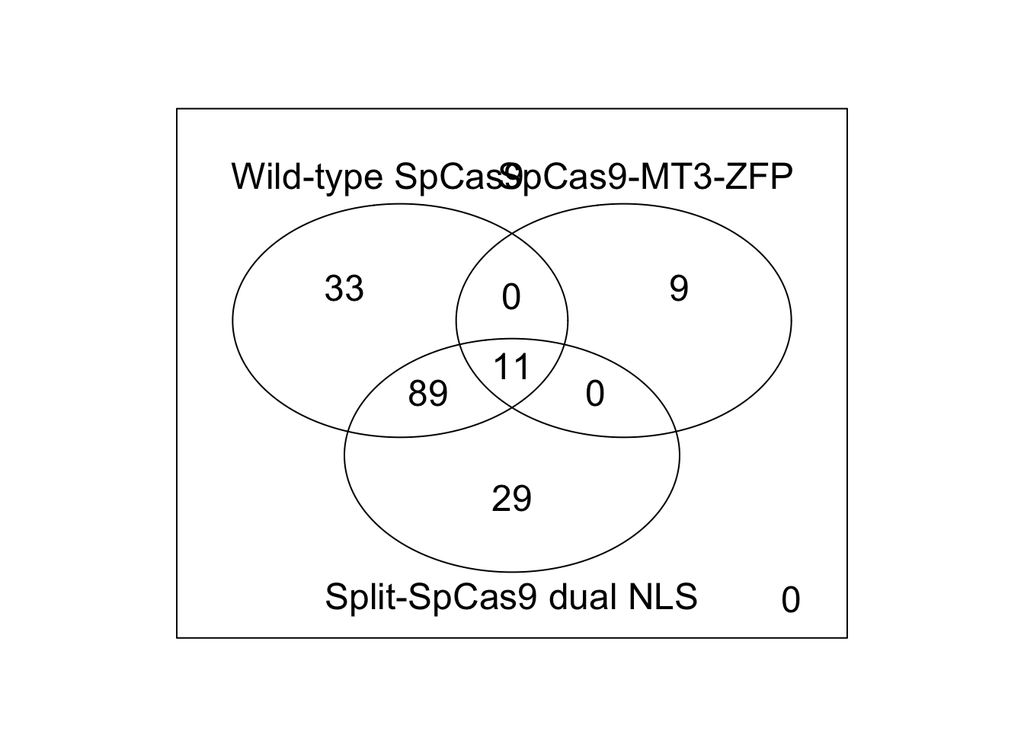

```
##                    offTarget predicted_cleavage_score gRNA.name
## 1 chr1:-:178738721:178738743                      0.1        T2
## 2 chr1:-:237195675:237195697                      0.0        T2
## 3   chr1:-:51442186:51442208                      0.1        T2
## 4   chr1:-:78245430:78245452                      0.1        T2
## 5   chr1:+:11714529:11714551                      0.8        T2
## 6 chr1:+:151031869:151031891                      0.1        T2
##               gRNAPlusPAM      offTarget_sequence guideAlignment2OffTarget
## 1 GACCCCCTCCACCCCGCCTCCGG GGCCCTCTCCACTCCACCTCAGG     .G...T......T..A....
## 2 GACCCCCTCCACCCCGCCTCCGG AACCCCACCCACCCCATCTCAGG     A.....AC.......AT...
## 3 GACCCCCTCCACCCCGCCTCCGG GACCCCTCCCTCCCCACCTCAGG     ......TC..T....A....
## 4 GACCCCCTCCACCCCGCCTCCGG TCTCCACCCCACCCCGCCCCTGG     TCT..A.C..........C.
## 5 GACCCCCTCCACCCCGCCTCCGG GACCCGCCCCGCCCCGCCTCTGG     .....G.C..G.........
## 6 GACCCCCTCCACCCCGCCTCCGG CCTCCCCCACACCCCGCATCCGG     CCT....CA........A..
##   offTargetStrand mismatch.distance2PAM n.PAM.mismatch n.guide.mismatch
```

[output cut: 27 more lines]

If desired, combineOfftargets can be used to remove off-targets common among different gRNAs by setting remove.common to TRUE. Furthermore, if a control sample without nuclease is available, peaks present in the control sample can be removed from the gRNA samples by setting the control.sample.name.

# Exercise 1. Analysis of NmCas9 GUIDE-seq data

Hint: Compared to SpCas9, NmCas9 has a longer gRNA (24 nucleotides), and different PAM sequence preference (NNNNGATT)

# Exercise 2. Analysis of Cpf1 GUIDE-seq data

Hint: Compared to SpCas9, Cpf1 has a different PAM sequence preference (TTTN), which locates on the 5’ side of the protospacer unlike SpCas9 or NmCas9 which recognizes an NGG PAM on the 3’ side of the protospacer.